# M3: Time Series Decomposition Assignment

## Assignment Instructions:

Use the data in the file ConstructionTimeSeriesDatav2.csv, which was distributed with the course files within the M3 folder.

- This data describes private and public spending on construction in the United States from 2002 through 2013 with partial data for 2014.
- Data source: U.S. Census Bureau (https://www.census.gov/construction/c30/historical_data.html)
- Decompose the private and public spending data series using the most appropriate of the two time series decomposition methods that were demonstrated in the videos.

Similar to the methods used during the class lectures, a general model for the Private and Public spending on Construction data. Specifically, using this model:

$H\left(m \right) = T\left( m \right) + C\left( m \right) + \epsilon \left( m \right)$

where

- $H\left( m \right)$ = Monthly Spend (in Millions of Dollars) $m$
- $m$ = the index of the month
- $T\left( m \right)$ = $T$ represents the trend of the data which, in this case, could be nonlinear. $T\left( m \right)$ is the trend value for Month $m$.
- $C\left( m \right)$ = Cyclicality demand component which plays an analogous role to seasonality, $S\left( q \right)$, except that the pattern repeats after period whose duration might not be one year.
- $\epsilon \left( m \right)$ is the portion of demand that we will not be able to fit with $T \left(m \right)$ and $C \left( m \right)$.

```python
import pandas as pd
import numpy as np
import matplotlib.pyplot as plt
%matplotlib inline
```

Load and visualize the data

```python
""" Import the Construction Time Series Data CSV File into Jupyter"""
df = pd.read_csv('ConstructionTimeSeriesDatav2.csv')
df.index = pd.to_datetime(df['Month-Year'], format='%b-%y') # Uses the Month-Year column for functions below
dfAppendix = df # Used for the appendix at the end of the document
df.head() # To see the different data elements
```

| Month-Year | Month | Month-Year | Total Construction | Private Construction | Public Construction |
| --- | --- | --- | --- | --- | --- |
| 2002-01-01 | 1 | Jan-02 | 59516 | 45273 | 14243 |
| 2002-02-01 | 2 | Feb-02 | 58588 | 44475 | 14113 |
| 2002-03-01 | 3 | Mar-02 | 63782 | 49396 | 14386 |
| 2002-04-01 | 4 | Apr-02 | 69504 | 53283 | 16221 |
| 2002-05-01 | 5 | May-02 | 73384 | 55009 | 18375 |

[figure not shown]

```python
fig,ax = plt.subplots(nrows=1,ncols=2)
fig.suptitle('Value of Construction Put in Place (From 2002 through Feb 2014)')

fig.set_figheight(6)
fig.set_figwidth(14)
# Private
ax[0].plot(df['Private Construction'],label='Private Construction')
ax[0].set_xlabel('Year')
ax[0].set_ylabel('Value of Construction Put in Place (In Millions of $)')
ax[0].spines['right'].set_visible(False)
ax[0].spines['top'].set_visible(False)
ax[0].set_title('Private Construction Value')
# Public
ax[1].plot(df['Public Construction'],label='Public Construction')
ax[1].set_xlabel('Year')
ax[1].set_ylabel('Value of Construction Put in Place (In Millions of $)')
ax[1].spines['right'].set_visible(False)
ax[1].spines['top'].set_visible(False)
ax[1].set_title('Public Construction Value')
```

For Both the Private and Public Construction Values, there seems to be a non-linear trend.

The next cell was written to determine the optimal window sizes for both the Private and the Public Construction Values.

For this notebook, I've commented out the script below as it takes a while to run through the for loops. For the rest of the Jupyter notebook, the scripts are written without taking into account the analysis below as the script is run in an Appendix at the end of the document.

```python
"""
df1 = dfAppendix

df1['Pri_MovAvg'] = np.NaN
df1['Pri_sqErr'] = np.NaN
# Can't add the public at the same time, or it results in an error with the calculation of the window size.
df1['Pub_MovAvg'] = np.NaN
df1['Pub_sqErr'] = np.NaN

#df1.index = pd.to_datetime(df['Month-Year'], format='%b-%y')
#df1.index = pd.DatetimeIndex(freq='M', start=pd.Timestamp(year=2002, month=1, day=1), periods = len(df1['Private Construction']))

#print(len(data),'\n',data)

# Determine the Appropriate window size for Public and Private Construction
winPriPub = pd.DataFrame(data = list(range(20,50)), columns = ['windowSize'])
winPriPub['PriAvgSqErr']=np.NaN
winPriPub['PubAvgSqErr']=np.NaN
for win in range(len(winPriPub)):
    window = winPriPub['windowSize'][win]
    window = window - window % 2
    dfLoop = df1
    dfLoop2 = df1
    # Compute the moving average in the loop below using a window centered on the data point whose average is being computed
    for i in range(int(window/2),dfLoop.shape[0]-int(window/2)):
        dfLoop.loc[dfLoop.index[i],'Pri_MovAvg'] = (0.5*dfLoop.iloc[i - int(window/2)]['Private Construction'] + dfLoop.iloc[i - int(window/2)+1:i + int(window/2)]['Private Construction'].sum() + 0.5*dfLoop.iloc[i + int(window/2)]['Private Construction'])/float(window)
    for i in range(int(window/2),dfLoop2.shape[0]-int(window/2)):
        dfLoop2.loc[dfLoop2.index[i],'Pub_MovAvg'] = (0.5*dfLoop2.iloc[i - int(window/2)]['Public Construction'] + dfLoop2.iloc[i - int(window/2)+1:i + int(window/2)]['Public Construction'].sum() + 0.5*dfLoop2.iloc[i + int(window/2)]['Public Construction'])/float(window)
    dfLoop['Pri_sqErr'] = (dfLoop['Private Construction'] - dfLoop['Pri_MovAvg'])**2
    dfLoop2['Pub_sqErr'] = (dfLoop2['Public Construction'] - dfLoop2['Pub_MovAvg'])**2
    # The moving average cannot be applied to all rows and we need to delete those rows because we cannot use them in the analysis
    dfLoop.dropna(how='any',inplace=True)
    dfLoop2.dropna(how='any',inplace=True)
    winPriPub['PriAvgSqErr'][win]=sum(dfLoop['Pri_sqErr'])/len(dfLoop)
    winPriPub['PubAvgSqErr'][win]=sum(dfLoop2['Pub_sqErr'])/len(dfLoop2)

print(winPriPub)

fig,ax = plt.subplots()
ax.plot(winPriPub['windowSize'],winPriPub['PriAvgSqErr'],label='Private Construction Average Square Error')
ax.plot(winPriPub['windowSize'],winPriPub['PubAvgSqErr'],label='Public Construction Average Square Error')
ax.set_xlabel('Window Size')
ax.set_ylabel('Average Square Error')
ax.axvline(x=28,linewidth=1,color='k',label='Min Avg. Sq Error Private Construction',linestyle='-')
ax.axvline(x=30,linewidth=1,color='k',label='Min Avg. Sq Error Public Construction',linestyle='--')
ax.legend(bbox_to_anchor=(1.05, 1), loc='upper left', borderaxespad=0.)
ax.spines['right'].set_visible(False)
ax.spines['top'].set_visible(False)

"""
```

[output not shown]

The appropriate window size for the two respective data sets are 28 and 31 for the Private Construction Values and Public Construction Values, respectively.

Below will be the calculation of the average squared error for both the private and public contructions values for the window sizes mentioned above.

```
Private Construction Value, Average Squared Error per Month:  27906329
Private Construction Value, Cumulative Squared Error:  3292946778

            Month Month-Year  Private Construction        MovAvg         sqErr
Month-Year
2003-03-01     15     Mar-03                 49996  55003.142857  2.507148e+07
2003-04-01     16     Apr-03                 53195  55794.535714  6.757586e+06
2003-05-01     17     May-03                 56286  56639.857143  1.252149e+05
2003-06-01     18     Jun-03                 60076  57416.500000  7.072940e+06
2003-07-01     19     Jul-03                 62216  58065.982143  1.722265e+07

Public Construction Value, Average Squared Error per Month:  10162879
Public Construction Value, Cumulative Squared Error:  1178893933

            Month Month-Year  Public Construction        MovAvg         sqErr
Month-Year
2003-04-01     16     Apr-03                16444  17767.850000  1.752579e+06
2003-05-01     17     May-03                18187  18022.050000  2.720850e+04
2003-06-01     18     Jun-03                20301  18281.066667  4.080131e+06
2003-07-01     19     Jul-03                20755  18464.316667  5.247230e+06
2003-08-01     20     Aug-03                21957  18529.966667  1.174456e+07
```

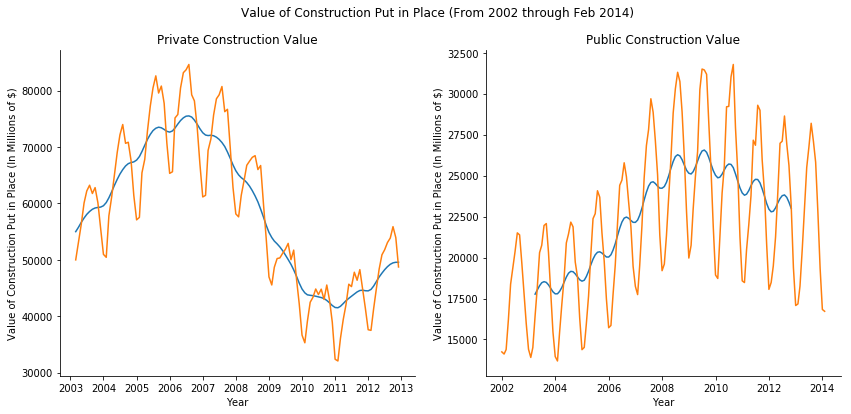

```python
df['MovAvg'] = np.NaN
df['sqErr'] = np.NaN

# Create a seperate DF for both the public and private construction values, as they will have different window sizes
dfPri = df.drop(['Total Construction','Public Construction'], axis=1)
dfPub = df.drop(['Total Construction','Private Construction'], axis=1)

winPri = 28
winPub = 31

winPri = winPri - winPri % 2
winPub = winPub - winPub % 2

# Compute the moving average in the loop below using a window centered on the data point whose average is being computed
# Private
for i in range(int(winPri/2),dfPri.shape[0]-int(winPri/2)):
    dfPri.loc[dfPri.index[i],'MovAvg'] = (0.5*dfPri.iloc[i - int(winPri/2)]['Private Construction'] + dfPri.iloc[i - int(winPri/2)+1:i + int(winPri/2)]['Private Construction'].sum() + 0.5*dfPri.iloc[i + int(winPri/2)]['Private Construction'])/float(winPri)
dfPri['sqErr'] = (dfPri['Private Construction'] - dfPri['MovAvg'])**2

# Public
for i in range(int(winPub/2),dfPub.shape[0]-int(winPub/2)):
    dfPub.loc[dfPub.index[i],'MovAvg'] = (0.5*dfPub.iloc[i - int(winPub/2)]['Public Construction'] + dfPub.iloc[i - int(winPub/2)+1:i + int(winPub/2)]['Public Construction'].sum() + 0.5*dfPub.iloc[i + int(winPub/2)]['Public Construction'])/float(winPub)
dfPub['sqErr'] = (dfPub['Public Construction'] - dfPub['MovAvg'])**2

# The moving average cannot be applied to all rows and we need to delete those rows because we cannot use them in the analysis
dfPri.dropna(how='any',inplace=True)
dfPub.dropna(how='any',inplace=True)

fig,ax = plt.subplots(nrows=1,ncols=2)
fig.suptitle('Value of Construction Put in Place (From 2002 through Feb 2014)')

fig.set_figheight(6)
fig.set_figwidth(14)
# Private
ax[0].plot(dfPri['MovAvg'],label='Moving Average')
ax[0].plot(dfPri['Private Construction'],label='Private Construction')
ax[0].set_xlabel('Year')
ax[0].set_ylabel('Value of Construction Put in Place (In Millions of $)')
ax[0].spines['right'].set_visible(False)
ax[0].spines['top'].set_visible(False)
ax[0].set_title('Private Construction Value')
# Public
ax[1].plot(dfPub['MovAvg'],label='Moving Average')
ax[1].plot(df['Public Construction'],label='Public Construction')
ax[1].set_xlabel('Year')
ax[1].set_ylabel('Value of Construction Put in Place (In Millions of $)')
ax[1].spines['right'].set_visible(False)
ax[1].spines['top'].set_visible(False)
ax[1].set_title('Public Construction Value')

print('Private Construction Value, Average Squared Error per Month: ', round(sum(dfPri['sqErr'])/len(dfPri)))
print('Private Construction Value, Cumulative Squared Error: ', round(sum(dfPri['sqErr'])))
print('')
print(dfPri.head())
print('')
print('Public Construction Value, Average Squared Error per Month: ', round(sum(dfPub['sqErr'])/len(dfPub)))
print('Public Construction Value, Cumulative Squared Error: ', round(sum(dfPub['sqErr'])))
print('')
print(dfPub.head())
```

The residual construction values have yet to be explained, $R1$. That is computed by subtracting the moving average from the demand time series. Also, these are included in this code cell:

```python
dfPri['R1'] = dfPri['Private Construction'] - dfPri['MovAvg']
dfPri['R1Error'] = abs((dfPri['Private Construction'] - dfPri['R1'])/dfPri['Private Construction'])
dfPri.style.format({
    'MovAvg': '{:.1f}'.format,
    'sqErr': '{:,.1f}'.format,
    'R1': '{:,.1f}'.format,
    'R1Error': '{:,.3f}'.format
})
```

| Month-Year | Month | Month-Year | Private Construction | MovAvg | sqErr | R1 | R1Error |
| --- | --- | --- | --- | --- | --- | --- | --- |
| 2003-03-01 00:00:00 | 15 | Mar-03 | 49996 | 55003.1 | 25,071,479.6 | -5,007.1 | 1.100 |
| 2003-04-01 00:00:00 | 16 | Apr-03 | 53195 | 55794.5 | 6,757,585.9 | -2,599.5 | 1.049 |
| 2003-05-01 00:00:00 | 17 | May-03 | 56286 | 56639.9 | 125,214.9 | -353.9 | 1.006 |
| 2003-06-01 00:00:00 | 18 | Jun-03 | 60076 | 57416.5 | 7,072,940.2 | 2,659.5 | 0.956 |
| 2003-07-01 00:00:00 | 19 | Jul-03 | 62216 | 58066.0 | 17,222,648.2 | 4,150.0 | 0.933 |
| 2003-08-01 00:00:00 | 20 | Aug-03 | 63234 | 58578.6 | 21,672,516.4 | 4,655.4 | 0.926 |
| 2003-09-01 00:00:00 | 21 | Sep-03 | 61767 | 58974.1 | 7,800,350.3 | 2,792.9 | 0.955 |
| 2003-10-01 00:00:00 | 22 | Oct-03 | 62813 | 59198.7 | 13,063,448.5 | 3,614.3 | 0.942 |
| 2003-11-01 00:00:00 | 23 | Nov-03 | 60115 | 59295.5 | 671,609.5 | 819.5 | 0.986 |
| 2003-12-01 00:00:00 | 24 | Dec-03 | 55584 | 59357.0 | 14,235,529.0 | -3,773.0 | 1.068 |
| 2004-01-01 00:00:00 | 25 | Jan-04 | 50975 | 59595.9 | 74,320,717.3 | -8,620.9 | 1.169 |
| 2004-02-01 00:00:00 | 26 | Feb-04 | 50449 | 60161.6 | 94,335,431.3 | -9,712.6 | 1.193 |
| 2004-03-01 00:00:00 | 27 | Mar-04 | 57796 | 61004.4 | 10,293,899.3 | -3,208.4 | 1.056 |
| 2004-04-01 00:00:00 | 28 | Apr-04 | 61177 | 62076.3 | 808,779.0 | -899.3 | 1.015 |
| 2004-05-01 00:00:00 | 29 | May-04 | 65027 | 63203.5 | 3,325,152.2 | 1,823.5 | 0.972 |
| 2004-06-01 00:00:00 | 30 | Jun-04 | 69039 | 64273.5 | 22,710,330.6 | 4,765.5 | 0.931 |
| 2004-07-01 00:00:00 | 31 | Jul-04 | 72170 | 65215.1 | 48,370,534.7 | 6,954.9 | 0.904 |
| 2004-08-01 00:00:00 | 32 | Aug-04 | 74001 | 66001.6 | 63,990,857.5 | 7,999.4 | 0.892 |
| 2004-09-01 00:00:00 | 33 | Sep-04 | 70662 | 66649.8 | 16,097,576.9 | 4,012.2 | 0.943 |
| 2004-10-01 00:00:00 | 34 | Oct-04 | 70856 | 67060.8 | 14,403,380.4 | 3,795.2 | 0.946 |
| 2004-11-01 00:00:00 | 35 | Nov-04 | 67585 | 67257.8 | 107,069.2 | 327.2 | 0.995 |
| 2004-12-01 00:00:00 | 36 | Dec-04 | 61438 | 67371.7 | 35,209,177.1 | -5,933.7 | 1.097 |
| 2005-01-01 00:00:00 | 37 | Jan-05 | 57094 | 67690.6 | 112,288,082.9 | -10,596.6 | 1.186 |
| 2005-02-01 00:00:00 | 38 | Feb-05 | 57531 | 68320.0 | 116,401,750.4 | -10,789.0 | 1.188 |
| 2005-03-01 00:00:00 | 39 | Mar-05 | 65425 | 69207.6 | 14,308,251.9 | -3,782.6 | 1.058 |
| 2005-04-01 00:00:00 | 40 | Apr-05 | 67829 | 70319.4 | 6,202,145.5 | -2,490.4 | 1.037 |
| 2005-05-01 00:00:00 | 41 | May-05 | 72862 | 71366.8 | 2,235,772.6 | 1,495.2 | 0.979 |
| 2005-06-01 00:00:00 | 42 | Jun-05 | 77258 | 72248.5 | 25,095,448.1 | 5,009.5 | 0.935 |
| 2005-07-01 00:00:00 | 43 | Jul-05 | 80480 | 72921.9 | 57,124,713.7 | 7,558.1 | 0.906 |
| 2005-08-01 00:00:00 | 44 | Aug-05 | 82629 | 73339.8 | 86,289,502.0 | 9,289.2 | 0.888 |

[output cut: 88 more lines]

```python
dfPub['R1'] = dfPub['Public Construction'] - dfPub['MovAvg']
dfPub['R1Error'] = abs((dfPub['Public Construction'] - dfPub['R1'])/dfPub['Public Construction'])
dfPub.style.format({
    'MovAvg': '{:.1f}'.format,
    'sqErr': '{:,.1f}'.format,
    'R1': '{:,.1f}'.format,
    'R1Error': '{:,.3f}'.format
})
```

| Month-Year | Month | Month-Year | Public Construction | MovAvg | sqErr | R1 | R1Error |
| --- | --- | --- | --- | --- | --- | --- | --- |
| 2003-04-01 00:00:00 | 16 | Apr-03 | 16444 | 17767.8 | 1,752,578.8 | -1,323.8 | 1.081 |
| 2003-05-01 00:00:00 | 17 | May-03 | 18187 | 18022.0 | 27,208.5 | 165.0 | 0.991 |
| 2003-06-01 00:00:00 | 18 | Jun-03 | 20301 | 18281.1 | 4,080,130.7 | 2,019.9 | 0.901 |
| 2003-07-01 00:00:00 | 19 | Jul-03 | 20755 | 18464.3 | 5,247,230.1 | 2,290.7 | 0.890 |
| 2003-08-01 00:00:00 | 20 | Aug-03 | 21957 | 18530.0 | 11,744,557.5 | 3,427.0 | 0.844 |
| 2003-09-01 00:00:00 | 21 | Sep-03 | 22075 | 18485.8 | 12,882,595.9 | 3,589.2 | 0.837 |
| 2003-10-01 00:00:00 | 22 | Oct-03 | 20321 | 18334.5 | 3,946,116.0 | 1,986.5 | 0.902 |
| 2003-11-01 00:00:00 | 23 | Nov-03 | 17801 | 18118.2 | 100,615.8 | -317.2 | 1.018 |
| 2003-12-01 00:00:00 | 24 | Dec-03 | 15466 | 17910.6 | 5,976,150.6 | -2,444.6 | 1.158 |
| 2004-01-01 00:00:00 | 25 | Jan-04 | 13959 | 17785.7 | 14,643,505.3 | -3,826.7 | 1.274 |
| 2004-02-01 00:00:00 | 26 | Feb-04 | 13689 | 17790.0 | 16,817,790.9 | -4,101.0 | 1.300 |
| 2004-03-01 00:00:00 | 27 | Mar-04 | 15443 | 17935.0 | 6,209,897.9 | -2,492.0 | 1.161 |
| 2004-04-01 00:00:00 | 28 | Apr-04 | 17177 | 18179.8 | 1,005,574.4 | -1,002.8 | 1.058 |
| 2004-05-01 00:00:00 | 29 | May-04 | 18709 | 18487.2 | 49,180.5 | 221.8 | 0.988 |
| 2004-06-01 00:00:00 | 30 | Jun-04 | 20893 | 18809.7 | 4,340,208.3 | 2,083.3 | 0.900 |
| 2004-07-01 00:00:00 | 31 | Jul-04 | 21444 | 19047.2 | 5,744,730.1 | 2,396.8 | 0.888 |
| 2004-08-01 00:00:00 | 32 | Aug-04 | 22164 | 19158.2 | 9,034,633.3 | 3,005.8 | 0.864 |
| 2004-09-01 00:00:00 | 33 | Sep-04 | 21876 | 19137.7 | 7,498,469.4 | 2,738.3 | 0.875 |
| 2004-10-01 00:00:00 | 34 | Oct-04 | 19726 | 19006.7 | 517,392.5 | 719.3 | 0.964 |
| 2004-11-01 00:00:00 | 35 | Nov-04 | 18809 | 18821.1 | 146.4 | -12.1 | 1.001 |
| 2004-12-01 00:00:00 | 36 | Dec-04 | 16295 | 18646.4 | 5,529,003.6 | -2,351.4 | 1.144 |
| 2005-01-01 00:00:00 | 37 | Jan-05 | 14380 | 18560.4 | 17,475,604.8 | -4,180.4 | 1.291 |
| 2005-02-01 00:00:00 | 38 | Feb-05 | 14517 | 18617.5 | 16,814,373.6 | -4,100.5 | 1.282 |
| 2005-03-01 00:00:00 | 39 | Mar-05 | 15920 | 18836.7 | 8,507,236.1 | -2,916.7 | 1.183 |
| 2005-04-01 00:00:00 | 40 | Apr-05 | 17656 | 19165.2 | 2,277,684.6 | -1,509.2 | 1.085 |
| 2005-05-01 00:00:00 | 41 | May-05 | 20097 | 19546.2 | 303,380.6 | 550.8 | 0.973 |
| 2005-06-01 00:00:00 | 42 | Jun-05 | 22375 | 19905.8 | 6,096,948.6 | 2,469.2 | 0.890 |
| 2005-07-01 00:00:00 | 43 | Jul-05 | 22679 | 20167.2 | 6,308,888.1 | 2,511.8 | 0.889 |
| 2005-08-01 00:00:00 | 44 | Aug-05 | 24078 | 20323.5 | 14,096,145.1 | 3,754.5 | 0.844 |
| 2005-09-01 00:00:00 | 45 | Sep-05 | 23685 | 20352.5 | 11,105,445.2 | 3,332.5 | 0.859 |

[output cut: 86 more lines]

The cell below helps us visualize the remaining pattern to be decomposed, $R1$, and it also computes the average residual demand pattern.

```
Average Residual of Private Construction:  165.44
Cumulative Residual of Private Construction:  19522
Average Residual of Public Construction:  151.06
Cumulative Residual of Public Construction:  17523
```

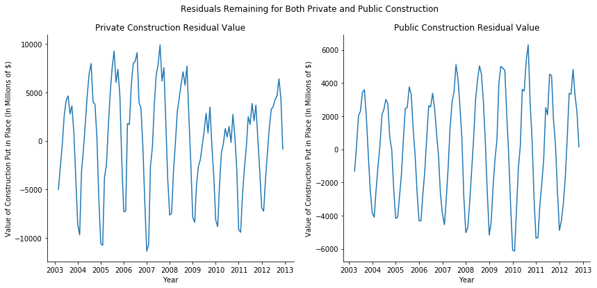

```python
fig,ax = plt.subplots(nrows=1,ncols=2)
fig.suptitle('Residuals Remaining for Both Private and Public Construction')

fig.set_figheight(6)
fig.set_figwidth(14)
# Private
ax[0].plot(dfPri['R1'])
ax[0].set_xlabel('Year')
ax[0].set_ylabel('Value of Construction Put in Place (In Millions of $)')
ax[0].spines['right'].set_visible(False)
ax[0].spines['top'].set_visible(False)
ax[0].set_title('Private Construction Residual Value')
# Public
ax[1].plot(dfPub['R1'])
ax[1].set_xlabel('Year')
ax[1].set_ylabel('Value of Construction Put in Place (In Millions of $)')
ax[1].spines['right'].set_visible(False)
ax[1].spines['top'].set_visible(False)
ax[1].set_title('Public Construction Residual Value')

print('Average Residual of Private Construction: ', round(sum(dfPri['R1'])/len(dfPri),2))
print('Cumulative Residual of Private Construction: ', round(sum(dfPri['R1'])))
print('Average Residual of Public Construction: ', round(sum(dfPub['R1'])/len(dfPub),2))
print('Cumulative Residual of Public Construction: ', round(sum(dfPub['R1'])))
```

Use autocorrelation analysis to detect whether any cyclical patterns exist and how many periods before they are repeated.

```python
# Private Construction First
maxCorr = 0.0
period = np.NaN
print('Private Construction Auto Correlation Analysis')
print('')
for i in range(1,37):
    corr = dfPri['R1'].autocorr(lag=i)
    print('Correlation, lag ',i,'   ',corr)
    if corr > maxCorr:
        maxCorr = corr
        period = i
print('period = ',period,'     Maximum Correlation = ',maxCorr)

print('')
# Public
maxCorr = 0.0
period = np.NaN
print('Public Construction Auto Correlation Analysis')
print('')
for i in range(1,37):
    corr = dfPub['R1'].autocorr(lag=i)
    print('Correlation, lag ',i,'   ',corr)
    if corr > maxCorr:
        maxCorr = corr
        period = i
print('period = ',period,'     Maximum Correlation = ',maxCorr)
```

```
Private Construction Auto Correlation Analysis

Correlation, lag  1     0.802817791693665
Correlation, lag  2     0.4443534589868593
Correlation, lag  3     0.020476842888635695
Correlation, lag  4     -0.3395526458258491
Correlation, lag  5     -0.5946355941654637
Correlation, lag  6     -0.7256392985138465
Correlation, lag  7     -0.626869741908392
Correlation, lag  8     -0.396315840672076
Correlation, lag  9     -0.0552300506808024
Correlation, lag  10     0.350135855726644
Correlation, lag  11     0.6979125314418182
Correlation, lag  12     0.8927182172333037
Correlation, lag  13     0.7167085973043467
Correlation, lag  14     0.38251474913428596
Correlation, lag  15     -0.01931861069919423
Correlation, lag  16     -0.36054942226148884
Correlation, lag  17     -0.598581299411287
Correlation, lag  18     -0.7205781836890767
Correlation, lag  19     -0.6202726789012772
Correlation, lag  20     -0.404890237189766
Correlation, lag  21     -0.08117295039341191
Correlation, lag  22     0.30735608489046207
Correlation, lag  23     0.6541025499187769
Correlation, lag  24     0.8505324832872295
Correlation, lag  25     0.6852622646661864
Correlation, lag  26     0.3568515204044749
Correlation, lag  27     -0.04113825315531122
Correlation, lag  28     -0.3798682515950228
Correlation, lag  29     -0.6147822258405803
Correlation, lag  30     -0.7380950796013821
Correlation, lag  31     -0.6433078216430518
Correlation, lag  32     -0.43509598498545665
Correlation, lag  33     -0.10655995897397513
Correlation, lag  34     0.27747484234202724
Correlation, lag  35     0.6101095216746676
Correlation, lag  36     0.7900934797419148
period =  12      Maximum Correlation =  0.8927182172333037

```

[output cut: 24 more lines]

```
Correlation, lag  23     0.8120287809524561
Correlation, lag  24     0.9618647472899124
Correlation, lag  25     0.8272377122632899
Correlation, lag  26     0.4908367195383105
Correlation, lag  27     0.030556461874966433
Correlation, lag  28     -0.4449559278355129
Correlation, lag  29     -0.7957011699236589
Correlation, lag  30     -0.9394496547665148
Correlation, lag  31     -0.8368464690588221
Correlation, lag  32     -0.5165016520416306
Correlation, lag  33     -0.06230043785619708
Correlation, lag  34     0.41443181667147705
Correlation, lag  35     0.7979467733207289
Correlation, lag  36     0.9602425552686529
period =  12      Maximum Correlation =  0.9732672393898196
```

For both the private and public construction data sets, both had the maximum correlation at 12 months.

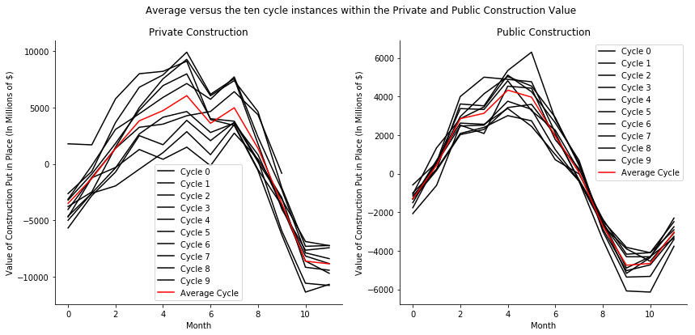

```python
period = 12
cycleLen = period
# Private
numCyclesPri = int(len(dfPri)/cycleLen + 0.5)
cyclesPri = [dfPri.iloc[range(i*period,min((i+1)*period,len(dfPri)))]['R1'] for i in range(numCyclesPri)]
ptsInCyclesPri = [dfPri.iloc[range(i,len(dfPri['R1']),period)]['R1'].tolist() for i in range(period)]
avgPri = [sum(pts)/len(pts) for pts in ptsInCyclesPri]
# Public
numCyclesPub = int(len(dfPub)/cycleLen + 0.5)
cyclesPub = [dfPub.iloc[range(i*period,min((i+1)*period,len(dfPub)))]['R1'] for i in range(numCyclesPub)]
ptsInCyclesPub = [dfPub.iloc[range(i,len(dfPub['R1']),period)]['R1'].tolist() for i in range(period)]
avgPub = [sum(pts)/len(pts) for pts in ptsInCyclesPub]

fig,ax = plt.subplots(nrows=1,ncols=2)
fig.suptitle('Average versus the ten cycle instances within the Private and Public Construction Value')
fig.set_figheight(6)
fig.set_figwidth(14)

for i in range(len(cyclesPri)):
    ax[0].plot(cyclesPri[i].values,label='Cycle '+str(i),c='k')
ax[0].plot(avgPri,label='Average Cycle',c='r')
ax[0].set_xlabel('Month')
ax[0].set_ylabel('Value of Construction Put in Place (In Millions of $)')
ax[0].spines['right'].set_visible(False)
ax[0].spines['top'].set_visible(False)
ax[0].set_title('Private Construction')
ax[0].legend()

for i in range(len(cyclesPub)):
    ax[1].plot(cyclesPub[i].values,label='Cycle '+str(i),c='k')
ax[1].plot(avgPub,label='Average Cycle',c='r')
ax[1].set_xlabel('Month')
ax[1].set_ylabel('Value of Construction Put in Place (In Millions of $)')
ax[1].spines['right'].set_visible(False)
ax[1].spines['top'].set_visible(False)
ax[1].set_title('Public Construction')
ax[1].legend()
```

This code cell:

Inserts the appropriate 𝐶(𝑚) value into the 𝐶 column in the DataFrame for each Month 𝑚 . Plots the cyclicality component 𝐶(𝑚) is plotted with the 𝑅1 column to see how well the cyclicality component and it match.

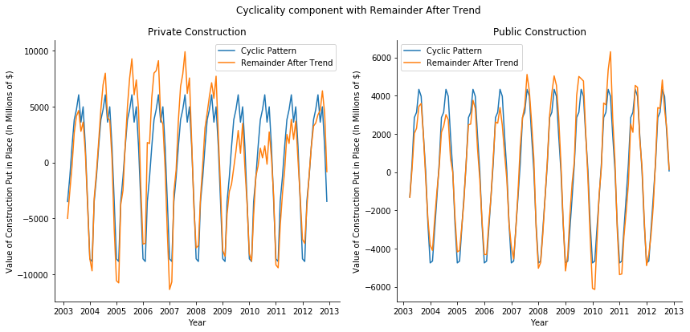

```python
# Private
dfPri['C'] = np.NaN   # Creates an empty column for the cyclicality component data

for i in range(len(dfPri)):
    dfPri.loc[dfPri.index[i], 'C'] = avgPri[i % cycleLen] # Write appropriate cyclicality value

# Public
dfPub['C'] = np.NaN   # Creates an empty column for the cyclicality component data

for i in range(len(dfPub)):
    dfPub.loc[dfPub.index[i], 'C'] = avgPub[i % cycleLen] # Write appropriate cyclicality value

fig,ax = plt.subplots(nrows=1,ncols=2)
fig.suptitle('Cyclicality component with Remainder After Trend')
fig.set_figheight(6)
fig.set_figwidth(14)

ax[0].plot(dfPri['C'],label='Cyclic Pattern')
ax[0].plot(dfPri['R1'],label='Remainder After Trend')
ax[0].set_xlabel('Year')
ax[0].set_ylabel('Value of Construction Put in Place (In Millions of $)')
ax[0].spines['right'].set_visible(False)
ax[0].spines['top'].set_visible(False)
ax[0].set_title('Private Construction')
ax[0].legend()

ax[1].plot(dfPub['C'],label='Cyclic Pattern')
ax[1].plot(dfPub['R1'],label='Remainder After Trend')
ax[1].set_xlabel('Year')
ax[1].set_ylabel('Value of Construction Put in Place (In Millions of $)')
ax[1].spines['right'].set_visible(False)
ax[1].spines['top'].set_visible(False)
ax[1].set_title('Public Construction')
ax[1].legend()
```

The code cell below executes the following:

- Computes the remaining residual home sales to be explained, $R2$, after subtracting the cyclical component, $C \left( m \right)$: this is the $\epsilon \left( m \right)$ in our model.
- Computes the error, $R2$, as a percentage of the demand time series.
- Computes the mathematical model 'fit', composed of the trend and cyclical components: $T\left( m \right) + C\left( m \right)$.
- Plots the fit of the model $T\left( m \right) + C\left( m \right)$ with the original data, $H \left( m \right)$.
- Computes the average absolute error of $R2Error$ of the original demand time series.
- Retains the sqErr column because shows the trend data relative to the original data series for each month, and calculates the cumulative square error as well.

```python
# Private
# Monthly squared Error - Rewrites the previous squared error to include the entire model
dfPri['sqErr'] = (dfPri['Private Construction'] - dfPri['MovAvg'] - dfPri['C'])**2
# As R1 was the original residuals R2X is the residual remaining from both the Cyclic and Trend
dfPri['R2X'] = dfPri['R1'] - dfPri['C']
dfPri['R2ErrorX'] = abs(dfPri['R2X']/dfPri['Private Construction'])
dfPri['fit'] = dfPri['MovAvg'] + dfPri['C']
print('Private Construction:')
print('Cumulative Squared Error: ', round(sum(dfPri['sqErr'])))
print('Average Error: ', round(sum(dfPri['R2ErrorX'])/len(dfPri),3))
print('')
print(dfPri)
```

```
Private Construction:
Cumulative Squared Error:  495360485
Average Error:  0.029
            Month Month-Year  Private Construction        MovAvg  \
Month-Year
2003-03-01     15     Mar-03                 49996  55003.142857
2003-04-01     16     Apr-03                 53195  55794.535714
2003-05-01     17     May-03                 56286  56639.857143
2003-06-01     18     Jun-03                 60076  57416.500000
2003-07-01     19     Jul-03                 62216  58065.982143
2003-08-01     20     Aug-03                 63234  58578.625000
2003-09-01     21     Sep-03                 61767  58974.089286
2003-10-01     22     Oct-03                 62813  59198.660714
2003-11-01     23     Nov-03                 60115  59295.482143
2003-12-01     24     Dec-03                 55584  59357.000000
2004-01-01     25     Jan-04                 50975  59595.946429
2004-02-01     26     Feb-04                 50449  60161.642857
2004-03-01     27     Mar-04                 57796  61004.410714
2004-04-01     28     Apr-04                 61177  62076.321429
2004-05-01     29     May-04                 65027  63203.500000
2004-06-01     30     Jun-04                 69039  64273.464286
2004-07-01     31     Jul-04                 72170  65215.107143
2004-08-01     32     Aug-04                 74001  66001.571429
2004-09-01     33     Sep-04                 70662  66649.821429
2004-10-01     34     Oct-04                 70856  67060.821429
2004-11-01     35     Nov-04                 67585  67257.785714
2004-12-01     36     Dec-04                 61438  67371.732143
2005-01-01     37     Jan-05                 57094  67690.607143
2005-02-01     38     Feb-05                 57531  68319.964286
2005-03-01     39     Mar-05                 65425  69207.625000
2005-04-01     40     Apr-05                 67829  70319.410714
2005-05-01     41     May-05                 72862  71366.750000
2005-06-01     42     Jun-05                 77258  72248.464286
2005-07-01     43     Jul-05                 80480  72921.910714
2005-08-01     44     Aug-05                 82629  73339.785714
...           ...        ...                   ...           ...
2010-07-01    103     Jul-10                 43851  43436.857143
2010-08-01    104     Aug-10                 44803  43314.285714
2010-09-01    105     Sep-10                 42978  43136.053571
2010-10-01    106     Oct-10                 45539  42804.267857
```

[output cut: 141 more lines]

```
2011-12-01  0.009210  41032.575000
2012-01-01  0.046382  35866.533730
2012-02-01  0.043093  35882.095238
2012-03-01  0.012913  41837.346429
2012-04-01  0.002034  44872.532143
2012-05-01  0.000159  48349.682143
2012-06-01  0.011294  51474.866071
2012-07-01  0.023180  52994.576786
2012-08-01  0.033614  54856.992857
2012-09-01  0.019441  52826.644643
2012-10-01  0.025588  54457.950000
2012-11-01  0.055322  50957.833929
2012-12-01  0.054657  46076.003571

[118 rows x 11 columns]
```

```python
# Public
# Monthly squared Error - Rewrites the previous squared error to include the entire model
dfPub['sqErr'] = (dfPub['Public Construction'] - dfPub['MovAvg'] - dfPub['C'])**2
# As R1 was the original residuals R2X is the residual remaining from both the Cyclic and Trend
dfPub['R2X'] = dfPub['R1'] - dfPub['C']
dfPub['R2ErrorX'] = abs(dfPri['R2X']/dfPub['Public Construction'])
dfPub['fit'] = dfPub['MovAvg'] + dfPub['C']
print('Public Construction:')
print('Cumulative Squared Error: ', round(sum(dfPub['sqErr'])))
print('Average Error: ', round(sum(dfPub['R2ErrorX'])/len(dfPub),3))
print(dfPub)
```

```
Public Construction:
Cumulative Squared Error:  51042605
Average Error:  0.073
            Month Month-Year  Public Construction        MovAvg         sqErr  \
Month-Year
2003-04-01     16     Apr-03                16444  17767.850000  1.904860e+02
2003-05-01     17     May-03                18187  18022.050000  6.858463e+04
2003-06-01     18     Jun-03                20301  18281.066667  6.874870e+05
2003-07-01     19     Jul-03                20755  18464.316667  7.002036e+05
2003-08-01     20     Aug-03                21957  18529.966667  8.127924e+05
2003-09-01     21     Sep-03                22075  18485.766667  1.411580e+05
2003-10-01     22     Oct-03                20321  18334.516667  1.837837e+03
2003-11-01     23     Nov-03                17801  18118.200000  1.417108e+05
2003-12-01     24     Dec-03                15466  17910.616667  6.789595e+04
2004-01-01     25     Jan-04                13959  17785.683333  8.590475e+05
2004-02-01     26     Feb-04                13689  17789.950000  3.120609e+05
2004-03-01     27     Mar-04                15443  17934.966667  2.942118e+05
2004-04-01     28     Apr-04                17177  18179.783333  9.441178e+04
2004-05-01     29     May-04                18709  18487.233333  4.205370e+04
2004-06-01     30     Jun-04                20893  18809.683333  5.863960e+05
2004-07-01     31     Jul-04                21444  19047.183333  5.338470e+05
2004-08-01     32     Aug-04                22164  19158.233333  1.749844e+06
2004-09-01     33     Sep-04                21876  19137.666667  1.504572e+06
2004-10-01     34     Oct-04                19726  19006.700000  1.498943e+06
2004-11-01     35     Nov-04                18809  18821.100000  5.090109e+03
2004-12-01     36     Dec-04                16295  18646.383333  1.251758e+05
2005-01-01     37     Jan-05                14380  18560.383333  3.284988e+05
2005-02-01     38     Feb-05                14517  18617.533333  3.125265e+05
2005-03-01     39     Mar-05                15920  18836.716667  1.384457e+04
2005-04-01     40     Apr-05                17656  19165.200000  3.966139e+04
2005-05-01     41     May-05                20097  19546.200000  1.536691e+04
2005-06-01     42     Jun-05                22375  19905.800000  1.443101e+05
2005-07-01     43     Jul-05                22679  20167.250000  3.791050e+05
2005-08-01     44     Aug-05                24078  20323.516667  3.295908e+05
2005-09-01     45     Sep-05                23685  20352.516667  4.000057e+05
...           ...        ...                  ...           ...           ...
2010-06-01    102     Jun-10                29204  25592.966667  5.805703e+05
2010-07-01    103     Jul-10                29226  25710.600000  1.504936e+05
2010-08-01    104     Aug-10                31031  25686.466667  1.032154e+06
2010-09-01    105     Sep-10                31786  25488.416667  5.441209e+06
```

[output cut: 141 more lines]

```
2011-11-01  23819.611667
2011-12-01  20598.698148
2012-01-01  18201.235185
2012-02-01  18133.959259
2012-03-01  19791.903704
2012-04-01  21722.785000
2012-05-01  23757.886667
2012-06-01  26452.565000
2012-07-01  26904.865000
2012-08-01  28152.250000
2012-09-01  27641.460000
2012-10-01  25323.196667
2012-11-01  23062.211667

[116 rows x 11 columns]
```

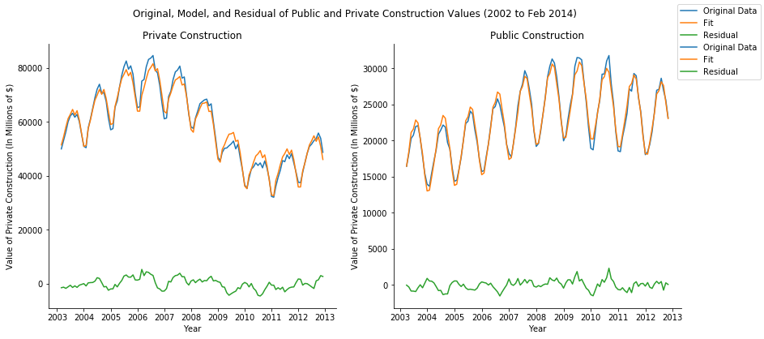

```python
fig,ax = plt.subplots(nrows=1,ncols=2)
fig.suptitle('Original, Model, and Residual of Public and Private Construction Values (2002 to Feb 2014)')
fig.set_figheight(6)
fig.set_figwidth(14)


ax[0].plot(dfPri['Private Construction'],label='Original Data')
ax[0].plot(dfPri['fit'],label='Fit')
ax[0].plot(dfPri['R2X'],label='Residual')
ax[0].set_xlabel('Year')
ax[0].set_ylabel('Value of Private Construction (In Millions of $)')
ax[0].spines['right'].set_visible(False)
ax[0].spines['top'].set_visible(False)
ax[0].set_title('Private Construction')
#ax[0].legend()

ax[1].plot(dfPub['Public Construction'],label='Original Data')
ax[1].plot(dfPub['fit'],label='Fit')
ax[1].plot(dfPub['R2X'],label='Residual')
ax[1].set_xlabel('Year')
ax[1].set_ylabel('Value of Private Construction (In Millions of $)')
ax[1].spines['right'].set_visible(False)
ax[1].spines['top'].set_visible(False)
ax[1].set_title('Public Construction')
fig.legend()
```

## Appendix - Script to Determine the "Optimial" Window Sizes

```python
df1 = dfAppendix

df1['Pri_MovAvg'] = np.NaN
df1['Pri_sqErr'] = np.NaN
# Can't add the public at the same time, or it results in an error with the calculation of the window size.
df1['Pub_MovAvg'] = np.NaN
df1['Pub_sqErr'] = np.NaN

#df1.index = pd.to_datetime(df['Month-Year'], format='%b-%y')
#df1.index = pd.DatetimeIndex(freq='M', start=pd.Timestamp(year=2002, month=1, day=1), periods = len(df1['Private Construction']))

#print(len(data),'\n',data)

# Determine the Appropriate window size for Public and Private Construction
winPriPub = pd.DataFrame(data = list(range(20,50)), columns = ['windowSize'])
winPriPub['PriAvgSqErr']=np.NaN
winPriPub['PubAvgSqErr']=np.NaN
for win in range(len(winPriPub)):
    window = winPriPub['windowSize'][win]
    window = window - window % 2
    dfLoop = df1
    dfLoop2 = df1
    # Compute the moving average in the loop below using a window centered on the data point whose average is being computed
    for i in range(int(window/2),dfLoop.shape[0]-int(window/2)):
        dfLoop.loc[dfLoop.index[i],'Pri_MovAvg'] = (0.5*dfLoop.iloc[i - int(window/2)]['Private Construction'] + dfLoop.iloc[i - int(window/2)+1:i + int(window/2)]['Private Construction'].sum() + 0.5*dfLoop.iloc[i + int(window/2)]['Private Construction'])/float(window)
    for i in range(int(window/2),dfLoop2.shape[0]-int(window/2)):
        dfLoop2.loc[dfLoop2.index[i],'Pub_MovAvg'] = (0.5*dfLoop2.iloc[i - int(window/2)]['Public Construction'] + dfLoop2.iloc[i - int(window/2)+1:i + int(window/2)]['Public Construction'].sum() + 0.5*dfLoop2.iloc[i + int(window/2)]['Public Construction'])/float(window)
    dfLoop['Pri_sqErr'] = (dfLoop['Private Construction'] - dfLoop['Pri_MovAvg'])**2
    dfLoop2['Pub_sqErr'] = (dfLoop2['Public Construction'] - dfLoop2['Pub_MovAvg'])**2
    # The moving average cannot be applied to all rows and we need to delete those rows because we cannot use them in the analysis
    dfLoop.dropna(how='any',inplace=True)
    dfLoop2.dropna(how='any',inplace=True)
    winPriPub['PriAvgSqErr'][win]=sum(dfLoop['Pri_sqErr'])/len(dfLoop)
    winPriPub['PubAvgSqErr'][win]=sum(dfLoop2['Pub_sqErr'])/len(dfLoop2)

print(winPriPub)

fig,ax = plt.subplots()
ax.plot(winPriPub['windowSize'],winPriPub['PriAvgSqErr'],label='Private Construction Average Square Error')
ax.plot(winPriPub['windowSize'],winPriPub['PubAvgSqErr'],label='Public Construction Average Square Error')
ax.set_xlabel('Window Size')
ax.set_ylabel('Average Square Error')
ax.axvline(x=28,linewidth=1,color='k',label='Min Avg. Sq Error Private Construction',linestyle='-')
ax.axvline(x=30,linewidth=1,color='k',label='Min Avg. Sq Error Public Construction',linestyle='--')
ax.legend(bbox_to_anchor=(1.05, 1), loc='upper left', borderaxespad=0.)
ax.spines['right'].set_visible(False)
ax.spines['top'].set_visible(False)
```

[output not shown]